# Project

## Project Proposal

### By: Benjamin Giese & Brady Cassada

#### Identify your dataset

Within our project there will be two datasets, one containing National Hockey League (NHL) team statistics and a second set that has attendance data by team and year. The team data includes each team's overall performance for a single year (wins, goals, penalty minutes, etc.). We plan to combine a subset of each of thes two data sets in order to explore relationships between team performance and attendance.

Team Data: We will be using the 'Teams.csv' from this dataset specifically. Dataset

Attendance Data: ESPN has public data of a Team's Home/Away/Overall attendance from 2000-Present day. This isn't already formatted as we will have to collect it all and clean it to our needs for analyzing. One year of data

We'll have to join these two datasets together in some way, this will be done via year and team name. Knowing the 'Teams.csv' data only goes up to 2011, and the ESPN data starts 2000 we will have completed data from the years 2000-2011.

#### Objectives for analyzing your dataset

Our goal is to find a relationship between and, ideally, predict attendance based on one or more of the following factors:

- Points
- Goals per game
- Penalty minutes

Some additional thoughts:

## Hypotheses/Problem

**Null**: An NHL teams' point totals have no effect on average home attendance  
**Alternative**: NHL teams' point totals have an effect on average home attendance

Along with this hypothesis, we want to be able to predict a team's average attendance based on their stats and performance. In order to accomplish this, we will create a linear regression model.

```python
# First Ten Records of Datset

import pandas as pd
#import matplotlib.pyplot as plt
import matplotlib.pyplot as plt
import seaborn as sns
%matplotlib inline

df = pd.read_csv('Teams.csv')

df = df.drop(df[df.year < 2000].index)
df = df.drop(df[df.lgID != "NHL"].index)
df = df.drop('lgID', 1)

for index, row in df.iterrows():
    if row['playoff'] not in ['CQF', 'CSF', 'CF', 'F', 'SC']:
        df.at[index, 'playoff'] = 'None'

df['year'] = df['year'].astype('category')
df['tmID'] = df['tmID'].astype('category')
df['confID'] = df['confID'].astype('category')
df['divID'] = df['divID'].astype('category')
df['playoff'] = df['playoff'].astype('category')
df['name'] = df['name'].astype('category')
df['rank'] = df['rank'].astype('category')

df = df.drop('franchID', 1)

attendance_df = pd.read_csv('attendance.csv')
# attendance_df.info()

def pull_city(full_name) :
    if ('New York' in full_name):
        name_split = full_name.split()
        return "NY " + name_split[2]
    elif ('New ' in full_name or 'St. ' in full_name or 'Los ' in full_name or 'San ' in full_name or 'Tampa ' in full_name):
        name_split = full_name.split()
        return name_split[0] + ' ' + name_split[1]
    elif (' of ' not in full_name) :
        return full_name.split()[0]
    else :
        name_split = full_name.split()
        return name_split[len(name_split) - 1]



df['name'] = df['name'].map(lambda name: pull_city(name))
```

```python
attendance_df = attendance_df.drop('Home Percentage', 1)
attendance_df = attendance_df.drop('Road Percentage', 1)
attendance_df = attendance_df.drop('Percentage', 1)

# Replace Arizona with Phoenix and replace Winnipeg with Atlanta
for index, row in attendance_df.iterrows():
    if row['Team'] == 'Arizona':
        attendance_df.at[index, 'Team'] = 'Phoenix'
    elif row['Team'] == 'Winnipeg' and row['Year'] != 2011:
        attendance_df.at[index, 'Team'] = 'Atlanta'



attendance_df['Rank'] = attendance_df['Rank'].astype('category')
attendance_df['Team'] = attendance_df['Team'].astype('category')
attendance_df['Year'] = attendance_df['Year'].astype('category')
attendance_df = attendance_df.rename(columns={"Rank": 'Attendance Rank'})

combined_df = pd.merge(df, attendance_df,  how='right', left_on=['name','year'], right_on = ['Team','Year'])
combined_df = combined_df.drop('Year', 1)
combined_df = combined_df.drop('Games', 1)
combined_df = combined_df.drop('Team', 1)

combined_df = combined_df.rename(columns={"rank": "division rank"})
```

# The Data Set

- year - Denotes which season the stats are from
- lgID - Id of the league that the team belongs to
  - This column was dropped because we are only focusing on one league (NHL)
- tmID - Id that denotes which team the stats are for
- confID - Denotes the conference that the team plays in
  - The NHL is split into 2 conferences - Eastern Conference & Western Conference
- divID - Id of the division that the team plays in
  - AT = Atlantic Division
  - CE = Central Division
  - NE = Northeast Division
  - NW = Northwest Division
  - PC = Pacific Division
  - SE = Southeast Division
- rank - The final standing of the team within their division
- playoff - The playoff round that the team made it to
  - CQF = Lost in Conference Quarter Final
  - CSF = Lost in Conference Semi-Final
  - CF = Lost in Conference Final
  - F = Lost in Stanley Cup final
  - SC = Won Stanley Cup final (championship)
- G - total games played
- W - total wins
  - Worth 2 points
- L - total losses
- T - total ties
  - Ties were only possible prior to the 2005 season, the NHL then switched to an overtime syste,
  - A tie is worth 1 point
- OTL - overtime losses
- Pts - total point
- SoW - total shootout wins
- SoL - total shootout losses
- GF - goals for
- GA - goals against
- name - name of the team (city)
- PIM - penalty minutes
- BenchMinor - penalty minutes as a result of bench minors
  - Bench minors include penalties such as:
    - Too many men on the ice
    - Unsportsmanlike conduct by the coach
    - Delay of game
- PPG - power play goals
- PPC - power play chances
- SHA - short handed goals against
- PKG - power play goals against
- PKC - penalty kill chances
- SHF - shorthanded goals for
- Attendance Rank - attendance ranking relative to all other teams in the league
- Home Games - total home games played
- Home Total Attendance - total attendance for all home games
- Home Average Attendance - average attendance for home games
- Road Games - total away games played
- Road Average - average attendance for away games
- Average - overall average attendance

# Data Preprocessing

Luckily for us, the NHL data collection is pretty thorough and doesn't leave many missing values. However, there is one exception due to a rule change before the 2005 season. Previously, the NHL did not have any type of overtime and games could end in a tie. Starting in 2005, a 5 minute sudden-death overtime would be played in the event of a tie. If neither team scored in the 5 minutes, a shootout would then decide the game. This results in no values for overtime losses or shootout wins/losses prior to 2005. Additionally, only years prior to 2005 have values for ties.  
Fortunately, ties and and overtime losses are both worth 1 point. This means we can use points as an independent variable that is more or less standardized when it comes to this discrepency.

While we didn't have to worry about many missing values, we had to do some cleaning to make sure that we could properly combine our 2 data sets. We joined the data by team name and year into a single dataframe. However, our team stats data listed team names as the full name (ex. Philadelphia Flyers) while the attendance data listed teams just by the city (Philadelphia). We ended up writing a function that pulls the city names out of the full name and mapped the original team stats dataframe to be consistent with our attendance data. We also had to deal with a couple cases where teams moved and/or changed their name. In 2011, the Atlanta Thrashers moved to Winnipeg and changed their name to the Winnipeg Jets. This was an issue because the attendance data listed rows for the Atlanta Thrasers under their new name (Winnipeg) even for years prior to the name change. Similarly, the Phoenix Coyotes changed their name to be the Arizona Coyotes in 2014. The attendance data once again listed all entries under the new name (Arizona) while the team data listed each of their entries under the name that they actually had at the time (Phoenix). Lucky for us, these were pretty simple fixes.

# Data Analysis and Visualization

Let's look at the distribution of each of these variables:

```python
import seaborn as sns
sns.set()

def plot_dist(col_name):
    plt.figure(figsize=(10, 8))
    sns.distplot(combined_df[col_name])
    print("Maximum: " + str(combined_df[col_name].max()))
    print("Minimum: " + str(combined_df[col_name].min()))
```

```
Maximum: 124
Minimum: 52
```

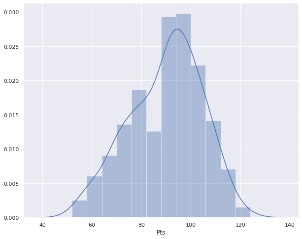

```python
plot_dist('Pts')
```

```
Maximum: 318
Minimum: 164
```

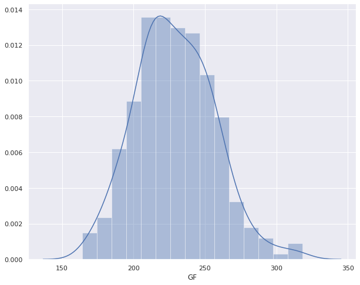

```python
plot_dist('GF')
```

```
Maximum: 1994.0
Minimum: 689.0
```

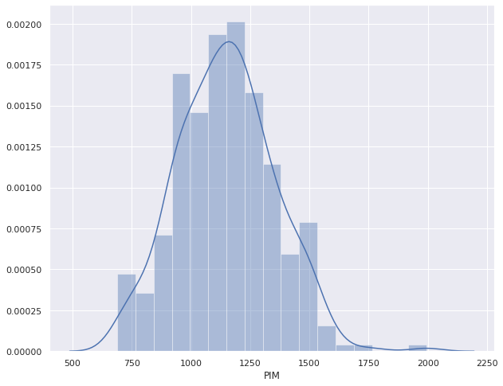

```python
plot_dist('PIM')
```

As you can see from the above plots, each of these variables has a relatively normal distribution and follow a decent bell curve.

Let's explore some basic linear relationships:

## Quantitative Analysis

```python
def plot_linear(col_name_x, col_name_y="Home Average Attendance"):
    plt.figure(figsize=(10, 8))
    sns.regplot(x=col_name_x, y=col_name_y, data=combined_df);
```

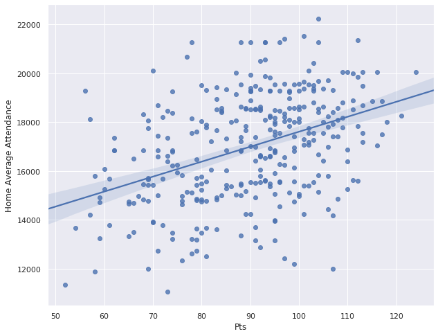

```python
plot_linear('Pts')
```

Clear positive correlation, as expected.

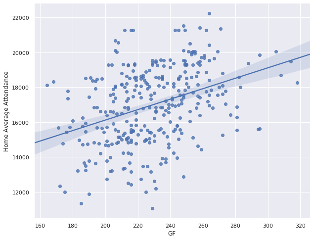

```python
plot_linear('GF')
```

Clear positive correlation, as expected. We are predicting that fans will want to see teams that score a lot of goals. Additonally, we will explore how goals for relates to points.

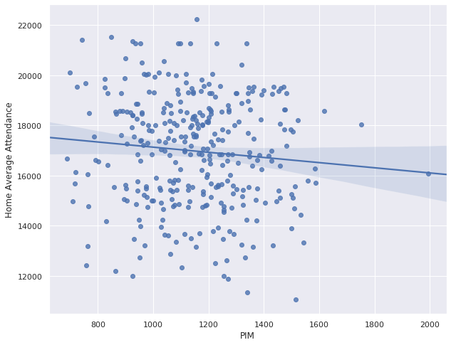

```python
plot_linear('PIM')
```

A bit of a negative correlation but nothing major. We actually expected there to be a positive correlation considering fights have a large impact on PIM totals (worth 5 PIM each). We assumed teams with more fights might have more fans looking to see some slugfests. However, teams with fewer penalty minutes will probably win more games (which we are assuming would increase attendance).

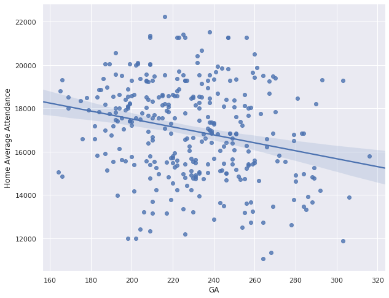

```python
plot_linear('GA')
```

### Correlation Coefficients

```python
from scipy.stats import pearsonr
def print_corr_and_p(display_name, col_name):
    corr_and_r = pearsonr(combined_df[col_name], combined_df['Home Average Attendance'])
    print(display_name)
    print('\t' + 'Correlation Coeff.: ' + str(corr_and_r[0]))
    print('\t' + 'p-value: ' + str(corr_and_r[1]))
    print()

print_corr_and_p("Points", "Pts")
print_corr_and_p("Goals For", "GF")
print_corr_and_p("Penalty Minutes", "PIM")
```

```
Points
	Correlation Coeff.: 0.4050633455304437
	p-value: 1.8408197620248627e-14

Goals For
	Correlation Coeff.: 0.3715572252925691
	p-value: 3.0510539112180646e-12

Penalty Minutes
	Correlation Coeff.: -0.09515359624939863
	p-value: 0.08436360890981646
```

For goals for and points we see moderate positive correlations. Relating this back to out hypothesis, our p-value is far less than a 0.03 significant level. This means that we reject the null hypothesis as we have evidence that points do have some effect on a team's average home attendance.

### Factors that Could Effect Points

Although we are not trying to use this data to predict points, the purpose of this section is purely for better understading how our points variable is shaped by other factors.

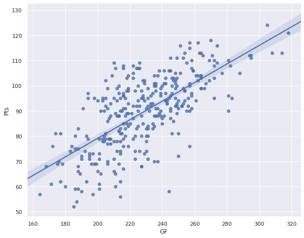

```python
plot_linear(col_name_x='GF', col_name_y='Pts')
```

Pretty strong positive correlation. Teams that score more goals win more games, not surprising.

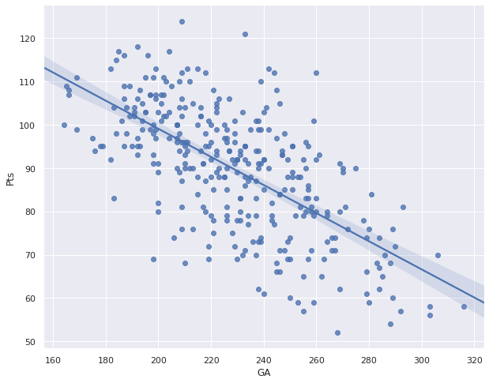

```python
plot_linear(col_name_x='GA', col_name_y='Pts')
```

Strong negative correlation. Give up less goals, win more games.

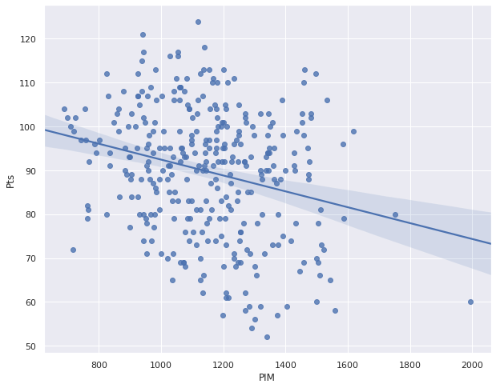

```python
plot_linear(col_name_x='PIM', col_name_y='Pts')
```

As we assumed, there is a negative correlation between penalty minutes and points. This would make since one would assume teams that spend less time shorthanded will have a better chance at winning games. Let's move on to basic statistical tests:

## Categorical Analysis

```python
def plot_boxplot(col_name, order=None):
    plt.figure(figsize=(10, 8))
    sns.boxplot(x=col_name, y='Home Average Attendance', data=combined_df, order=order)
```

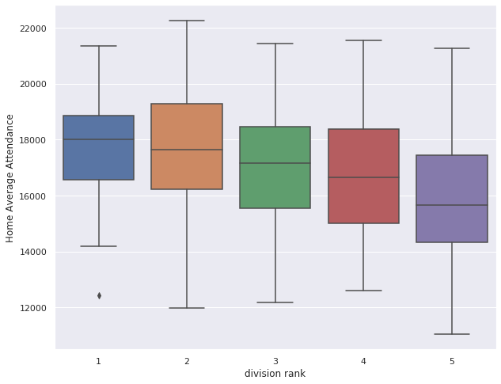

```python
plot_boxplot(col_name='division rank')
```

The boxplot above does show a bit of a downward trend in attendance as teams fall lower in the standings. These rankings are decided by points but also depend on the other teams in the divsion. This stat does compliment the points stat because teams that have less points but are in an "easier" division may be perceived to be more competitive which could contribute to attendance.

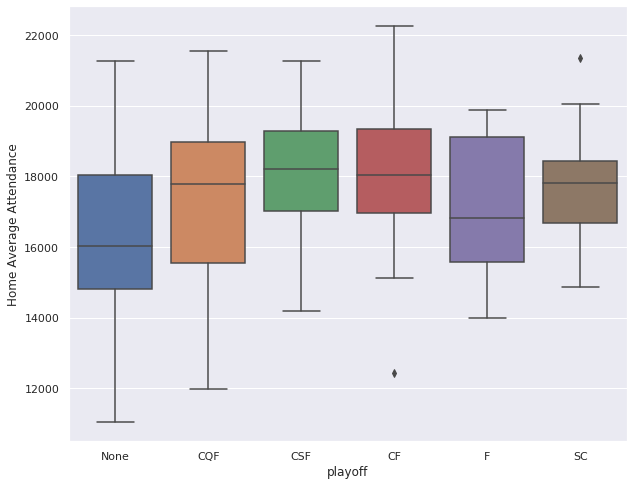

```python
order = ['None', 'CQF', 'CSF', 'CF', 'F', 'SC']
plot_boxplot('playoff', order=order)
```

This boxplot is ordered so that the worst possible playoff finish is on the left and progresses to the best finsih on the right. We don't see a super strong trend but it does appear that teams that make the playoffs typically have better attendance than those that don't.

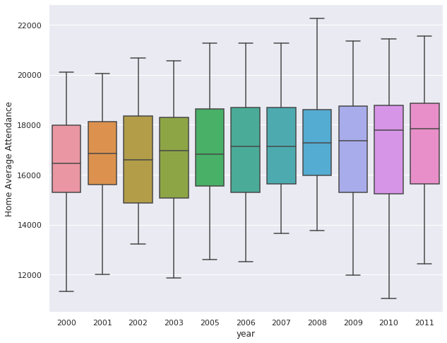

```python
plot_boxplot('year')
```

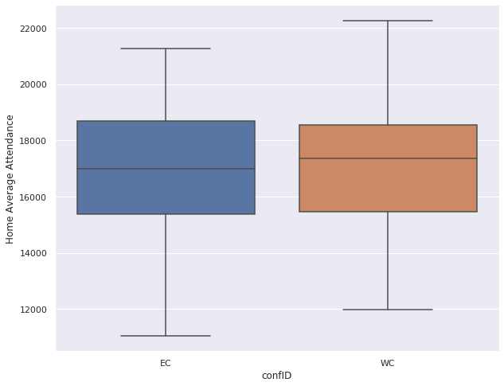

```python
plot_boxplot('confID')
```

Both conferences are pretty even as far as attendance goes.

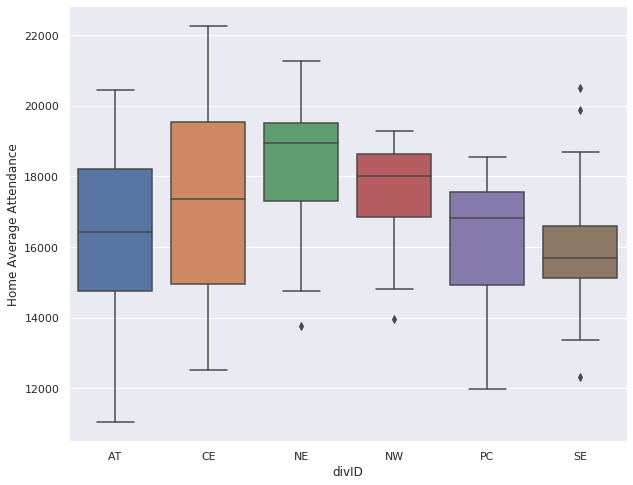

```python
plot_boxplot('divID')
```

We definitely see some differences here. It isn't really obvious why we would see a difference based on division but we will likely include this variable in our model creation considering there is definitely a difference between divisions.

# Data Modeling and Prediction

As stated before, we will be using points, goals for, and penalty minutes to try and predict attendance. This will be our first model since it includes the 3 main variables we picked from the beginning. We will then move on to some exploratory models.

```python
import numpy as np
from sklearn.linear_model import SGDRegressor
from sklearn.metrics import mean_squared_error
from sklearn.model_selection import train_test_split
from sklearn.preprocessing import Imputer
from sklearn.preprocessing import StandardScaler

# function from tutorial
def create_feature_matrices(df_train, df_test, selected_columns, dummy_columns=None):
    """
    Creates feature matrices for the training and testing sets from the given dataframes.
    The feature matrices are built from the columns given in selected columns.
    """

    if dummy_columns is None:
        dummy_columns = dict()

    # keep track of numerical features
    numerical_trial_columns = []

    # keep track of dummy features for categorical variables
    categorical_trial_columns = []

    # build feature lists
    for col_name in selected_columns:
        if col_name in dummy_columns:
            categorical_trial_columns.extend(dummy_columns[col_name])
        else:
            numerical_trial_columns.append(col_name)

    # transform numerical features
    if len(numerical_trial_columns) > 0:
        X_train_numerical = df_train[numerical_trial_columns].astype("float64").values
        X_test_numerical = df_test[numerical_trial_columns].astype("float64").values

        imputer = Imputer(missing_values=0)
        X_train_numerical = imputer.fit_transform(X_train_numerical)
        X_test_numerical = imputer.transform(X_test_numerical)

        scaler = StandardScaler()
        X_train_numerical = scaler.fit_transform(X_train_numerical)
        X_test_numerical = scaler.transform(X_test_numerical)

    # select categorical features
    if len(categorical_trial_columns) > 0:
        X_train_categorical = df_train[categorical_trial_columns].astype("float64").values
        X_test_categorical = df_test[categorical_trial_columns].astype("float64").values

    # concatenate feature matrices
    if len(numerical_trial_columns) > 0 and len(categorical_trial_columns) > 0:
        X_train = np.hstack([X_train_numerical, X_train_categorical])
        X_test = np.hstack([X_test_numerical, X_test_categorical])
    elif len(numerical_trial_columns) > 0:
        X_train = X_train_numerical
        X_test = X_test_numerical
    else:
        X_train = X_train_categorical
        X_test = X_test_categorical

    return X_train, X_test

def plot_predictions(predicted):
    plt.figure(figsize=(10, 8))
    sns.regplot(x=y_test, y=predicted, fit_reg=False)
    plt.plot([0, np.max(y_test)], [0, np.max(predicted)])
    plt.xlabel("True Attendance", fontsize=16)
    plt.ylabel("Predicted Attendance", fontsize=16)
```

```python
columns = ['Pts', 'GF', 'PIM']

df_train, df_test = train_test_split(combined_df)

X_train, X_test = create_feature_matrices(df_train, df_test, columns)

y_train = df_train["Home Average Attendance"].values
y_test = df_test["Home Average Attendance"].values

lr = SGDRegressor(max_iter=5000)
lr.fit(X_train, y_train)
predicted_test = lr.predict(X_test)

mse = mean_squared_error(y_test, predicted_test)
rmse = np.sqrt(mse)
print()
print("Model MSE:", mse)
print("Model RMSE:", rmse)
```

```
Model MSE: 3500371.7195360716
Model RMSE: 1870.9280369741834
```

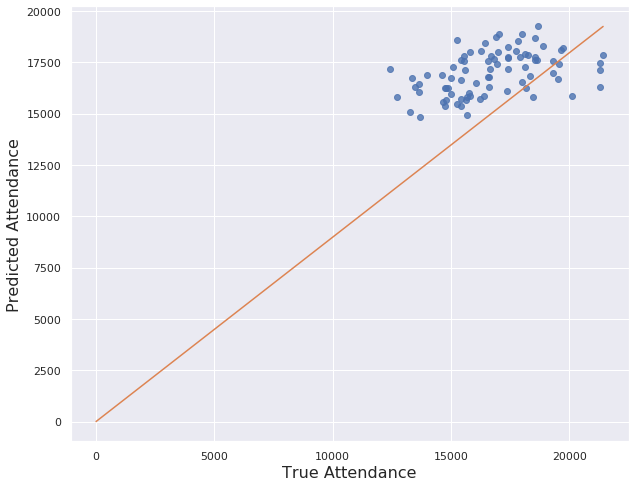

```python
plot_predictions(predicted_test)
```

To contrast the previous model, we will be adding in more of the variables. We don't really think that these vairables are very predictive of attendance but we're going to explore the possibility regardless.

```python
numerical_columns = ["Pts", "GF", "PIM", "PPG", "PPC", "SHA", "PKG", "SHF"]
categorical_columns = ["divID", "division rank", "playoff", "tmID"]
selected_columns = numerical_columns + categorical_columns

dummy_columns = {}
for col_name in categorical_columns:
    dummies = pd.get_dummies(combined_df[col_name], prefix=col_name)
    dummy_columns[col_name] = dummies.columns.values
    combined_df = combined_df.merge(dummies, left_index=True, right_index=True)
    combined_df = combined_df.drop(columns=col_name)

df_train, df_test = train_test_split(combined_df)

X_train, X_test = create_feature_matrices(df_train, df_test, numerical_columns, dummy_columns=dummy_columns)

y_train = df_train["Home Average Attendance"].values
y_test = df_test["Home Average Attendance"].values

lr = SGDRegressor(max_iter=5000)
lr.fit(X_train, y_train)
predicted_with_cat = lr.predict(X_test)

mse = mean_squared_error(y_test, predicted_with_cat)
rmse = np.sqrt(mse)
print()
print("Model MSE:", mse)
print("Model RMSE:", rmse)
```

```
Model MSE: 4917149.7488909
Model RMSE: 2217.464711983237
```

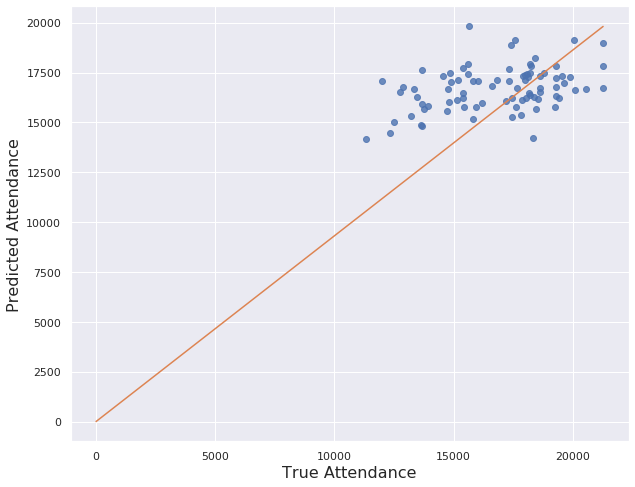

```python
plot_predictions(predicted_with_cat)
```

While this model wasn't far off from the first, there was more error. For our last model, we will create a model for each of our variables and use their sorted mean square error values to sort them. Starting with the model with the least amount of error, we will add another variable to the model, if the error goes down we will keep it, if not, we will throw it out and move on.

## Greedy Approach

```python
def sort_columns(df_train, df_test, y_train, y_test, all_columns, dummy_columns=None):
    column_rmses = []

    for col_name in all_columns:
        X_train, X_test = create_feature_matrices(df_train,
                                                 df_test,
                                                 [col_name],
                                                 dummy_columns=dummy_columns)

        simple_lr = SGDRegressor(max_iter=5000)
        simple_lr.fit(X_train, y_train)
        pred_prices_simple_test = simple_lr.predict(X_test)
        simple_mse = mean_squared_error(y_test, pred_prices_simple_test)
        simple_rmse = np.sqrt(simple_mse)
        print()
        print(col_name + " Model MSE:", simple_mse)
        print(col_name + " Model RMSE:", simple_rmse)
        column_rmses.append((simple_rmse, col_name))

    column_rmses.sort(key=lambda p: p[0])
    sorted_columns = [col_name for _, col_name in column_rmses]
    print()
    print("Sorted columns:" + str(sorted_columns))

    return sorted_columns

def select_features(df_train, df_test, y_train, y_test, sorted_columns, dummy_columns=None):
    lr = SGDRegressor(max_iter=5000)

    train_zeros = np.zeros((y_train.shape[0], 1))
    test_zeros = np.zeros((y_test.shape[0], 1))
    lr.fit(train_zeros, y_train)
    pred_y_test = lr.predict(test_zeros)

    null_mse = mean_squared_error(y_test, pred_y_test)
    null_rmse = np.sqrt(null_mse)

    base_model_columns = []
    base_rmse = null_rmse
    base_mse = null_mse

    print("Base Model MSE:", base_mse)
    print("Base Model RMSE:", base_rmse)
    print()

    for col_name in sorted_columns:
        # track all column names
        trial_columns = base_model_columns[:]
        trial_columns.append(col_name)

        X_train, X_test = create_feature_matrices(df_train,
                                                  df_test,
                                                  trial_columns,
                                                  dummy_columns=dummy_columns)

        lr = SGDRegressor(max_iter=5000)
        lr.fit(X_train, y_train)
        pred_y_test = lr.predict(X_test)
        trial_mse = mean_squared_error(y_test, pred_y_test)
        trial_rmse = np.sqrt(trial_mse)
        print()
        print(str(trial_columns) + " Model MSE:", trial_mse)
        print(str(trial_columns) + " Model RMSE:", trial_rmse)

        if trial_rmse < base_rmse:
            print("Updating base model")
            base_rmse = trial_rmse
            base_mse = trial_mse
            base_model_columns = trial_columns

        print()
        print("Base Model MSE:", base_mse)
        print("Base Model RMSE:", base_rmse)
        print()

    print("Our chosen columns are: " + str(base_model_columns))
    return base_model_columns
```

```python
sorted_columns = sort_columns(df_train, df_test, y_train, y_test, selected_columns, dummy_columns)
```

```
Pts Model MSE: 5014568.21426899
Pts Model RMSE: 2239.3231598563416

GF Model MSE: 5208440.354569343
GF Model RMSE: 2282.2007699957826

PIM Model MSE: 5978796.539530426
PIM Model RMSE: 2445.1577739545614

PPG Model MSE: 5222392.412802409
PPG Model RMSE: 2285.2554371015967

PPC Model MSE: 5892920.165702793
PPC Model RMSE: 2427.5337620109

SHA Model MSE: 5299766.410323598
SHA Model RMSE: 2302.1221536494536

PKG Model MSE: 5996475.810292519
PKG Model RMSE: 2448.7702649069633

SHF Model MSE: 5694635.554376234
SHF Model RMSE: 2386.3435532999506

divID Model MSE: 5047615.938553225
divID Model RMSE: 2246.689996094972

division rank Model MSE: 5487544.400647933
division rank Model RMSE: 2342.5508320307445

playoff Model MSE: 5445594.261727535
playoff Model RMSE: 2333.5797097437094

tmID Model MSE: 2045511.369095577
tmID Model RMSE: 1430.2137494429205

Sorted columns:['tmID', 'Pts', 'divID', 'GF', 'PPG', 'SHA', 'playoff', 'division rank', 'SHF', 'PPC', 'PIM', 'PKG']
```

An interesting variable to include is tmID (team name). This essentially means the model will be considering the team's average attendance of previous years. It proved to be the best predictor of attendance on its own. We would guess this is because there are a lot of other factors that contribute to attendance outside of hockey entirely. Certain cities simply have more people and/or embrace their hockey teams much more than others. Maybe other major professional sports such as an NBA or NFL team in the same city pull some attention away from the NHL. Including the team in the model indirectly accounts for these factors. However, it does limit us in some way. If we have team id in tthis model, we won't be able to punch in some theoretical stats without an designating a team.

```python
selected_columns = select_features(df_train, df_test, y_train, y_test, sorted_columns, dummy_columns=dummy_columns)

X_train, X_test = create_feature_matrices(df_train, df_test, selected_columns, dummy_columns)


lr = SGDRegressor(max_iter=5000)
lr.fit(X_train, y_train)
greedy_test = lr.predict(X_test)

mse = mean_squared_error(y_test, greedy_test)
rmse = np.sqrt(mse)
```

```
Base Model MSE: 5743097.893057455
Base Model RMSE: 2396.4761407235947


['tmID'] Model MSE: 2047186.3091505612
['tmID'] Model RMSE: 1430.799185473126
Updating base model

Base Model MSE: 2047186.3091505612
Base Model RMSE: 1430.799185473126


['tmID', 'Pts'] Model MSE: 1687028.4922606654
['tmID', 'Pts'] Model RMSE: 1298.8566095842395
Updating base model

Base Model MSE: 1687028.4922606654
Base Model RMSE: 1298.8566095842395


['tmID', 'Pts', 'divID'] Model MSE: 1681680.904233786
['tmID', 'Pts', 'divID'] Model RMSE: 1296.7964004552857
Updating base model

Base Model MSE: 1681680.904233786
Base Model RMSE: 1296.7964004552857


['tmID', 'Pts', 'divID', 'GF'] Model MSE: 1652662.510152324
['tmID', 'Pts', 'divID', 'GF'] Model RMSE: 1285.5592207877178
Updating base model

Base Model MSE: 1652662.510152324
Base Model RMSE: 1285.5592207877178
```

```
['tmID', 'Pts', 'divID', 'GF', 'PPG'] Model MSE: 1717379.0063049523
['tmID', 'Pts', 'divID', 'GF', 'PPG'] Model RMSE: 1310.488079421157

Base Model MSE: 1652662.510152324
Base Model RMSE: 1285.5592207877178


['tmID', 'Pts', 'divID', 'GF', 'SHA'] Model MSE: 1647991.1212936817
['tmID', 'Pts', 'divID', 'GF', 'SHA'] Model RMSE: 1283.7410647376214
Updating base model

Base Model MSE: 1647991.1212936817
Base Model RMSE: 1283.7410647376214


['tmID', 'Pts', 'divID', 'GF', 'SHA', 'playoff'] Model MSE: 1705379.8609275448
['tmID', 'Pts', 'divID', 'GF', 'SHA', 'playoff'] Model RMSE: 1305.901933886134

Base Model MSE: 1647991.1212936817
Base Model RMSE: 1283.7410647376214


['tmID', 'Pts', 'divID', 'GF', 'SHA', 'division rank'] Model MSE: 1598785.266361961
['tmID', 'Pts', 'divID', 'GF', 'SHA', 'division rank'] Model RMSE: 1264.4308072654512
Updating base model

Base Model MSE: 1598785.266361961
Base Model RMSE: 1264.4308072654512


['tmID', 'Pts', 'divID', 'GF', 'SHA', 'division rank', 'SHF'] Model MSE: 1610827.3891679954
['tmID', 'Pts', 'divID', 'GF', 'SHA', 'division rank', 'SHF'] Model RMSE: 1269.183749174246

Base Model MSE: 1598785.266361961
Base Model RMSE: 1264.4308072654512


['tmID', 'Pts', 'divID', 'GF', 'SHA', 'division rank', 'PPC'] Model MSE: 1639815.0456131285
['tmID', 'Pts', 'divID', 'GF', 'SHA', 'division rank', 'PPC'] Model RMSE: 1280.5526328945361

Base Model MSE: 1598785.266361961
Base Model RMSE: 1264.4308072654512
```

```
['tmID', 'Pts', 'divID', 'GF', 'SHA', 'division rank', 'PIM'] Model MSE: 1728661.048297284
['tmID', 'Pts', 'divID', 'GF', 'SHA', 'division rank', 'PIM'] Model RMSE: 1314.7855522089083

Base Model MSE: 1598785.266361961
Base Model RMSE: 1264.4308072654512


['tmID', 'Pts', 'divID', 'GF', 'SHA', 'division rank', 'PKG'] Model MSE: 1617320.9605411966
['tmID', 'Pts', 'divID', 'GF', 'SHA', 'division rank', 'PKG'] Model RMSE: 1271.7393445754506

Base Model MSE: 1598785.266361961
Base Model RMSE: 1264.4308072654512

Our chosen columns are: ['tmID', 'Pts', 'divID', 'GF', 'SHA', 'division rank']
```

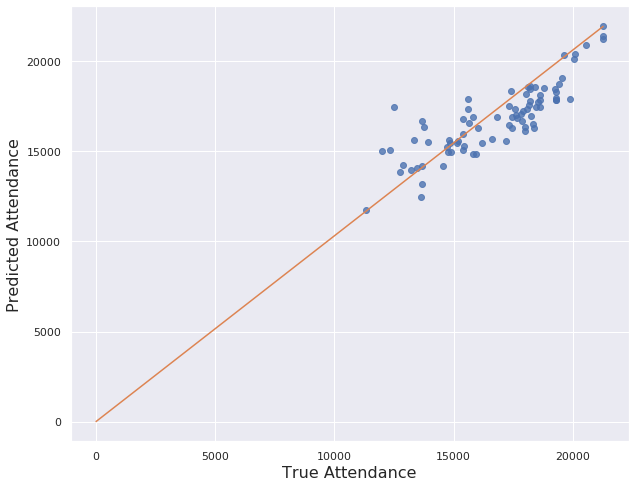

```python
plot_predictions(greedy_test)
```

With the greedy approach we produced the best model yet. Additionally, two of our predicted features (points and goals for) made it into the greedy model.  
Overall, we produced a model with an RSME of 1263.91. Let's take a quick look at the distribution of average home attendance to get a better idea of the significance of this number.

```
Maximum: 22247
Minimum: 11059
```

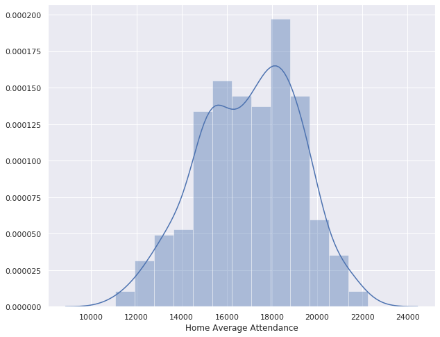

```python
plot_dist('Home Average Attendance')
```

Relative to the average attendance counts, being off by 1263 isn't necessarily small but it isn't very large either. If we were on a tight budget and needed to know exactly how many people we could expect to come and buy a ticket, we might not be able to rely too heavily on the model. However, if we want a general sense of what we can expect in the grand scheme of things, this model would be pretty reliable. We could at least get an idea of how the team's attendance stacks up against other teams in the league.

# Summary of Results